# A Visual Story of Online Advertisement Data

## Introduction

For this project, I put together a short visual breakdown of the online ads I’ve personally observed and tracked. All of the raw information comes from a simple Google Form I filled out whenever I saw an ad. I recorded things like what category the ad fell into, how long it ran for, the exact time I saw it, and how likely I would actually be to click on it myself.

The whole point of this analysis is pretty straightforward. I wanted to figure out which kinds of ads pop up the most regularly, how their runtime lengths compare against each other, and just how many of them actually feel interesting enough that someone might consider clicking through.

## Which advertisements appeared most often?

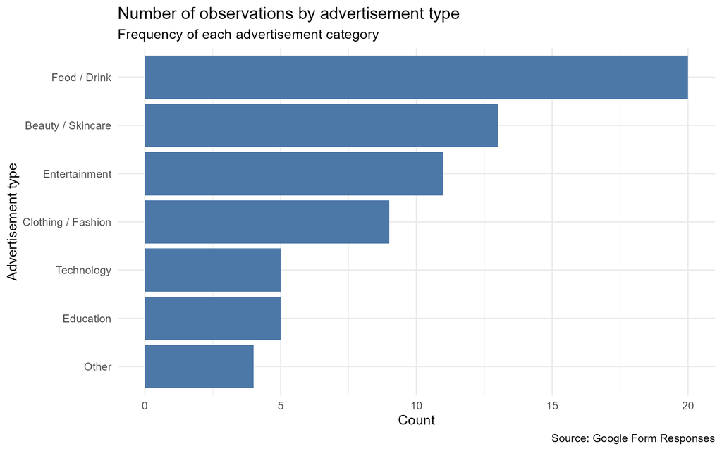

A bar chart showing the number of observations for each advertisement type.

This bar graph lays out exactly how many times each different category of ad showed up throughout all of my logged entries. It makes it really easy to quickly see which ad types dominated my browsing experience overall.

I think certain ad categories showed up way more often for two main reasons. First, they’re just super standard and common across the websites and apps I usually use. Second, platform recommendation algorithms tend to pick up on what I interact with, so they push similar content my way over and over.

## How long were the advertisements?

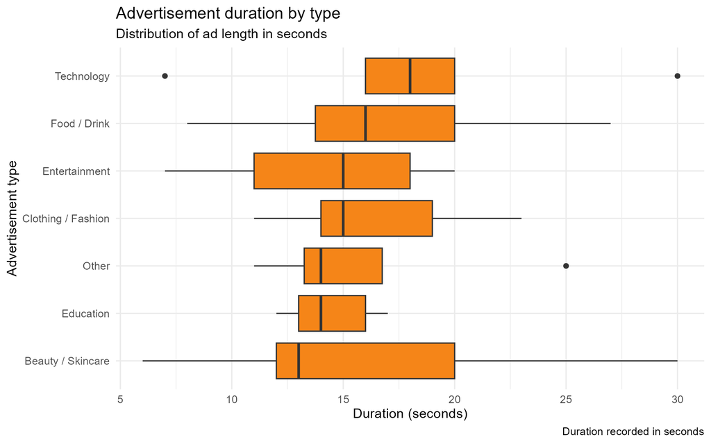

A boxplot comparing advertisement duration across different advertisement types.

This box and whisker plot compares the typical length of every different ad category I logged. You can clearly spot which types of ads are generally much longer, and which ones tend to be kept short.

You can also read how consistent each ad type’s runtime is from the width of the boxes. A much wider spread means the length of those ads was really inconsistent, while a tighter, narrower box means their runtime stayed pretty much the same every time.

## Were the advertisements likely to get clicks?

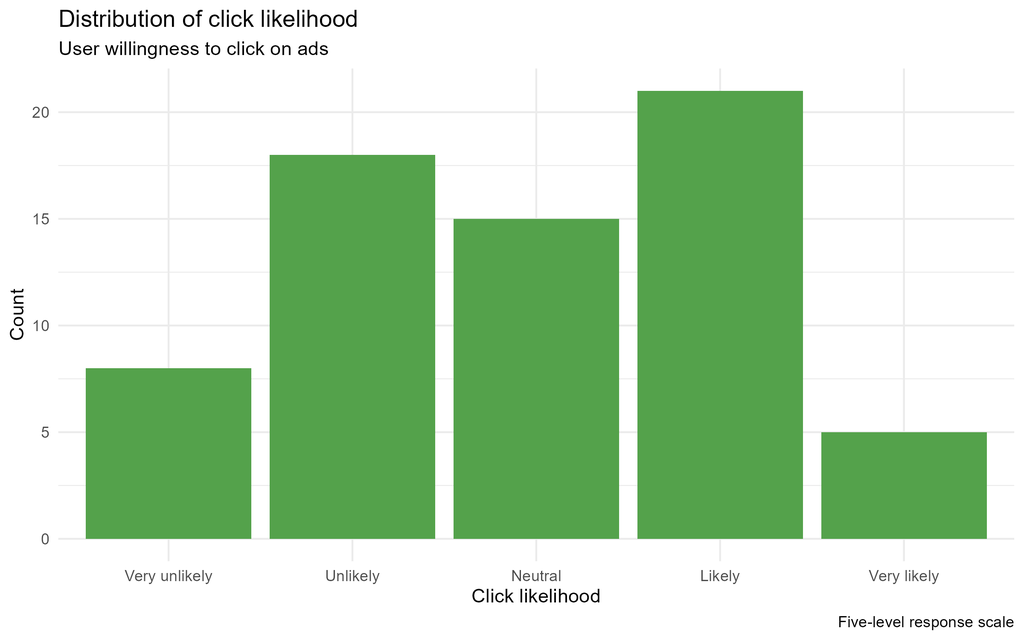

A bar chart showing the distribution of click likelihood from very unlikely to very likely.

This chart ranks how likely I was to click on any given ad, split across five simple ratings: very unlikely, unlikely, neutral, likely, and very likely.

This part is one of the most important takeaways. Just because an ad shows up constantly doesn’t automatically mean it’s actually good or effective. For an ad to work well, it also needs to grab your attention and actually spark some genuine interest.

## When was the data collected?

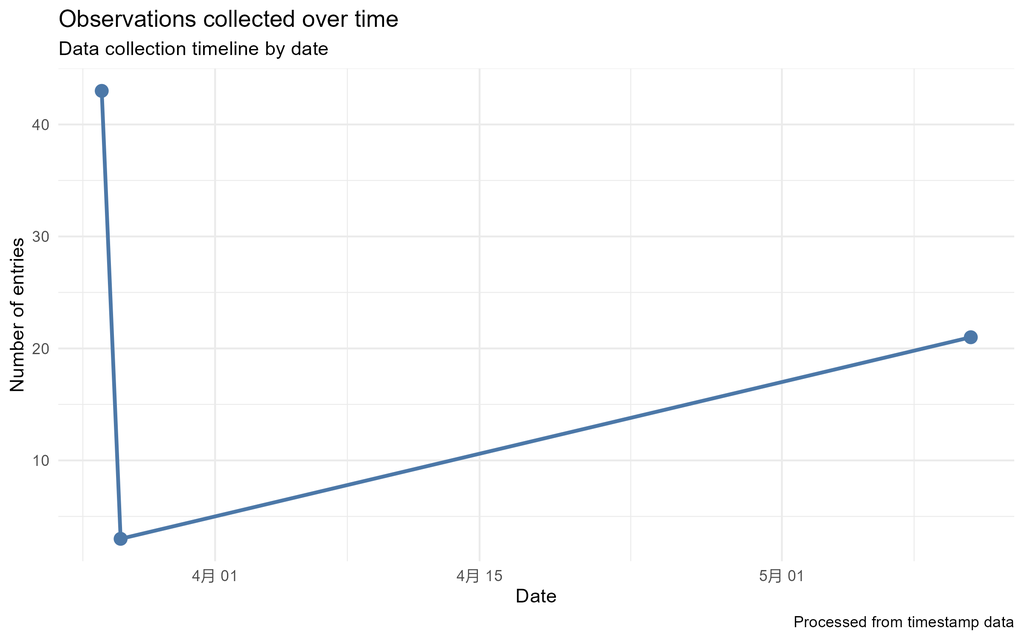

A line chart showing the number of observations collected on each date.

This simple line chart tracks how many ads I recorded on each individual day. It lets you see if I kept my logging roughly even day-to-day, or if I ended up noting way more ads on some random busy days.

It’s really important to point this out, because uneven logging can skew the whole dataset. For example, if I spent way more time online and logged dozens more ads on one single day, that day could end up heavily shifting all of the final results.

## Main message

At the end of the day, this whole analysis shows you can look at online ads in so many different ways. We can compare their category, their runtime length, how much people actually want to click them, and even when they’re most often shown.

All four of these graphs make really clear patterns visible: which ads you see the most, how long they usually last, and whether they actually feel engaging enough to make you click.

Going through this has given me a way better idea of how websites and apps decide which ads to show individual users, and just how big of a difference there is in how well different ad types actually perform.